# Course Project for the Statistical Inference Course as part of the Data Science Specialisation on Coursera

David Mullins

## Overview

There are two tasks for this course project. The first is a simulation exercise using the exponential distribution. The second is a basic inferential data analysis.

## Part 1 - Simulation Exercise

```r
## Simulate data for an exponential distribution

### Set variables
num_obs <- 40
lambda <- 0.2
num_simulations <- 1000
rseed <- set.seed(1) ## Set the random seed for reproducibility

## Simulate the data from the exponential distribution and arrange as a matrix
exp_sim.matrix <- matrix( rexp(num_obs*num_simulations, rate = lambda), num_simulations)

mns <- apply(exp_sim.matrix, 1, mean) ## Calculate the mean for each sample
vars <- apply(exp_sim.matrix, 1, var) ## Calculate the variance for each sample
```

### Sample Mean versus Theoretical Mean

The theoretical mean for the exponential distribution is 1/lambda. This works out as 5.

```r
## theoretical mean
tmean <- 1/lambda
tmean
```

```
## [1] 5
```

The sample mean for the 1,000 simulated distributions is 4.99.

```r
## Summary stats for the collective means of each simulated distribution
summary(mns)
```

```
##    Min. 1st Qu.  Median    Mean 3rd Qu.    Max.
##   3.085   4.417   4.924   4.990   5.530   8.059
```

```r
smean <- mean(mns)
smean
```

```
## [1] 4.990025
```

The below plot shows the distribution of the sample means of 1,000 simulated exponential distributions (with n=40 for each simulation). The theoretical mean is plotted in green at x=5. The sample mean is shown in red at x=4.99.

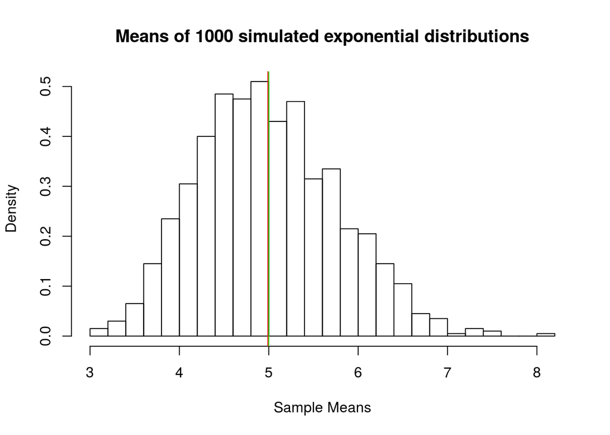

```r
hist(
    x = mns,
    breaks = 20,
    freq = FALSE,
    main = "Means of 1000 simulated exponential distributions",
    xlab = "Sample Means"
)
abline(v = tmean, col = "green")
abline(v = smean, col =  "red")
```

### Sample Variance versus Theoretical Variance

The theoretical standard deviation for the exponential distribution is 1/lambda. This works out as 5. The variance is the standard deviation squared. Therefore, the theoretical variance of the mean is 25.

```r
## theoretical variance
tvar <- (1/lambda)^2
tvar
```

```
## [1] 25
```

The sample variance of the means for the 1,000 simulated distributions is 25.06.

```r
## Summary stats for the collective means of each simulated distribution
summary(vars)
```

```
##    Min. 1st Qu.  Median    Mean 3rd Qu.    Max.
##   6.118  17.295  22.474  25.058  30.750  96.522
```

```r
## sample variance
svar <- mean(vars)
svar
```

```
## [1] 25.05783
```

The below plot shows the distribution of the sample variance of 1,000 simulated exponential distributions (with n=40 for each simulation). The theoretical variance is plotted in green at x=25. The mean sample variance is shown in red at x=25.06.

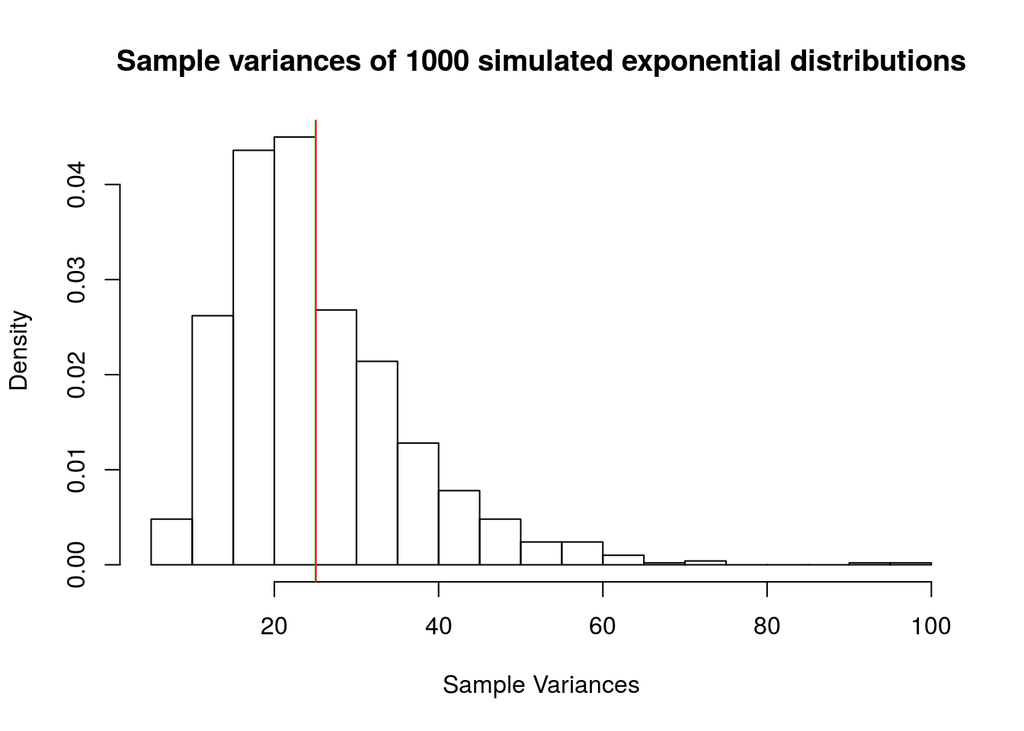

```r
hist(
    x = vars,
    breaks = 20,
    freq = FALSE,
    main = "Sample variances of 1000 simulated exponential distributions",
    xlab = "Sample Variances"
)
abline(v = tvar, col = "green")
abline(v = svar, col =  "red")
```

### Investigate Normality of the Distribution

```r
## If the mean and median are approximately the same, this is an indication of normality
mean(mns); median(mns)
```

```
## [1] 4.990025
```

```
## [1] 4.924455
```

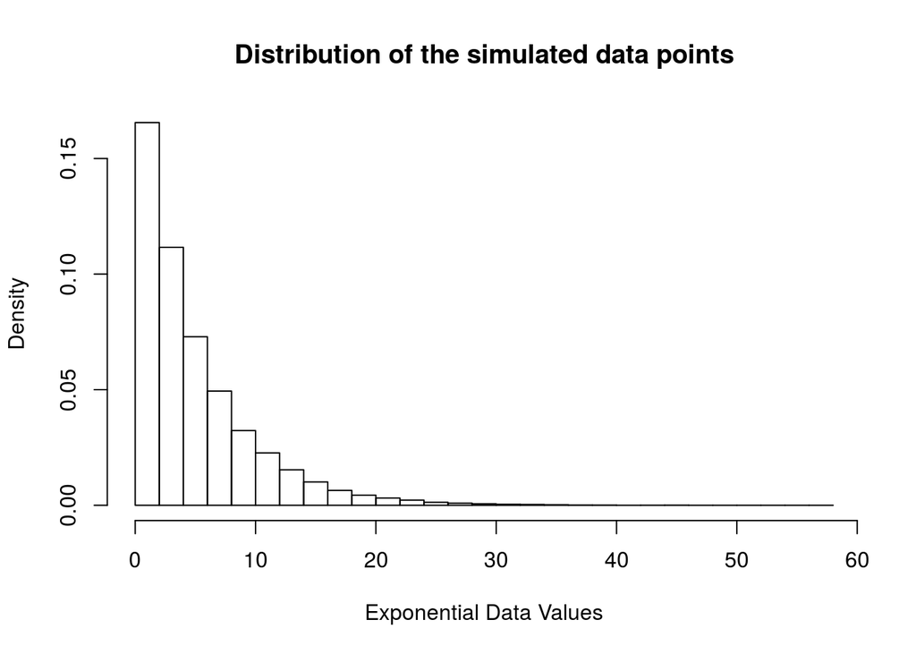

```r
## Plot a histogram of the distribution of the underlying data
hist(
    x = exp_sim.matrix,
    breaks = 30,
    freq = F,
    main = "Distribution of the simulated data points",
    xlab = "Exponential Data Values"
)
```

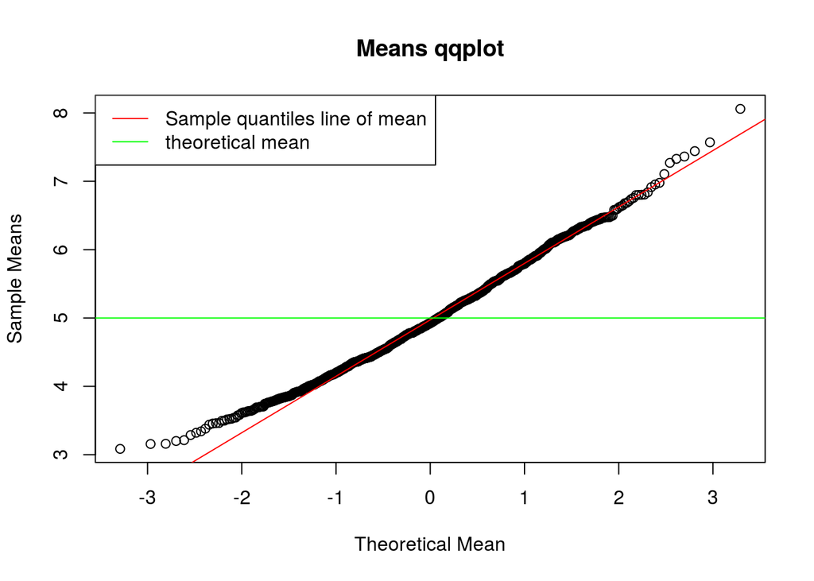

```r
## qqplot of the means distribution
qqnorm(
    mns,
    main = "Means qqplot",
    xlab = "Theoretical Mean",
    ylab = "Sample Means"
)
qqline(mns, col = "red")
abline(h = tmean, col = "green")
legend(
    "topleft",
    lty = 1,
    col = c("red", "green"),
    legend = c("Sample quantiles line of mean", "theoretical mean")
)
```

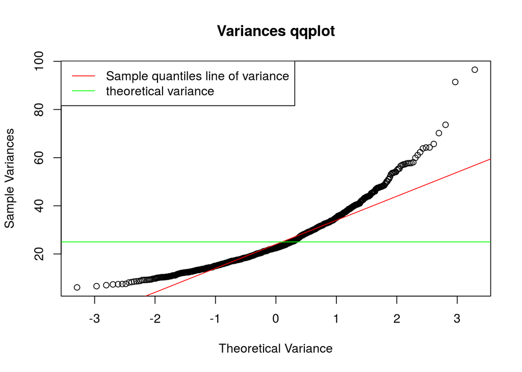

```r
## qqplot of the variances distribution
qqnorm(
    vars,
    main = "Variances qqplot",
    xlab = "Theoretical Variance",
    ylab = "Sample Variances"
)
qqline(vars, col = "red")
abline(h = tvar, col = "green")
legend(
    "topleft",
    lty = 1,
    col = c("red", "green"),
    legend = c("Sample quantiles line of variance", "theoretical variance")
)
```

## Part 2 - Basic Inferential Data Analysis

```r
library(datasets)
tg <- ToothGrowth
```

### Dataset description

The R output below summarises the variables in this dataset.

```r
str(tg); summary(tg)
```

```
## 'data.frame':    60 obs. of  3 variables:
##  $ len : num  4.2 11.5 7.3 5.8 6.4 10 11.2 11.2 5.2 7 ...
##  $ supp: Factor w/ 2 levels "OJ","VC": 2 2 2 2 2 2 2 2 2 2 ...
##  $ dose: num  0.5 0.5 0.5 0.5 0.5 0.5 0.5 0.5 0.5 0.5 ...
```

```
##       len        supp         dose
##  Min.   : 4.20   OJ:30   Min.   :0.500
##  1st Qu.:13.07   VC:30   1st Qu.:0.500
##  Median :19.25           Median :1.000
##  Mean   :18.81           Mean   :1.167
##  3rd Qu.:25.27           3rd Qu.:2.000
##  Max.   :33.90           Max.   :2.000
```

```r
tg$dose <- as.factor(tg$dose)
table(tg$supp, tg$dose)
```

```
##
##      0.5  1  2
##   OJ  10 10 10
##   VC  10 10 10
```

An initial visual investigation in the boxplot shown below would indicate that increased dosage of vitamin C increases the growth of teeth.

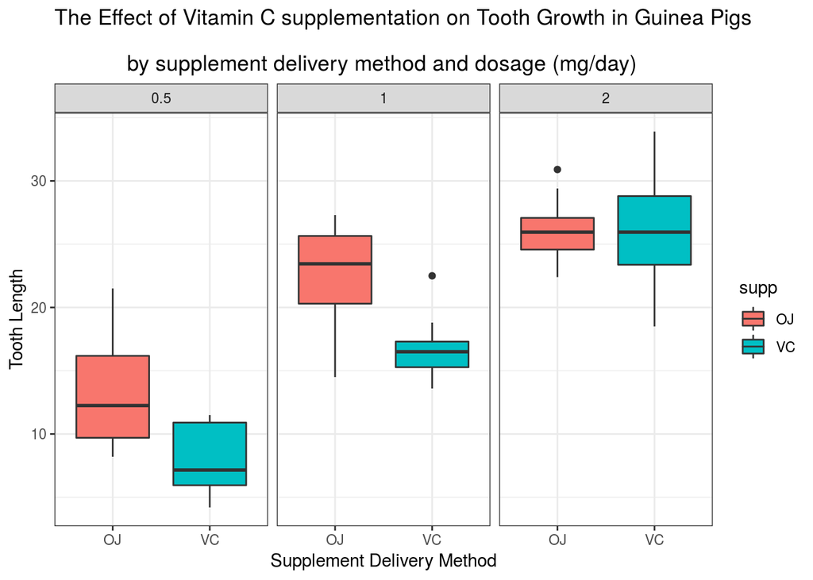

```r
library(ggplot2)
boxplots <- ggplot(data = tg, aes(x = supp, y = len, fill = supp)) +
    geom_boxplot() +
    facet_wrap(~ dose) +
    theme_bw() +
    ggtitle("The Effect of Vitamin C supplementation on Tooth Growth in Guinea Pigs\n\
            by supplement delivery method and dosage (mg/day)") +
    xlab("Supplement Delivery Method") +
    ylab("Tooth Length")
boxplots
```

### Statistical tests

#### T-test hypothesis and assumptions

**Hypothesis** The null and alternative hypotheses of a t-test are as follows: (Null) H0: mu1 = mu2 (Alt) HA: mu1 != mu2

In this case, the hypotheses represent whether the delivery method of vitamin C or the dosage have an effect on tooth growth length.

**Assumptions**

- An independent categorical variable that has two levels / groups.
- A continuous dependent variable.
- The observations are independent of each other.
- The dependent variable has a normal distribution with equal variance.

The data follows the first 3 assumptions. Each guinea pig is independent of each other. The plots below investigate whether the data is normal. Based on these plots the conclusion could be made that the data is approximately normal. The theoretical qqline and the sample mean in the Q-Q Plot intersect at approximately 0 on the x-axis.

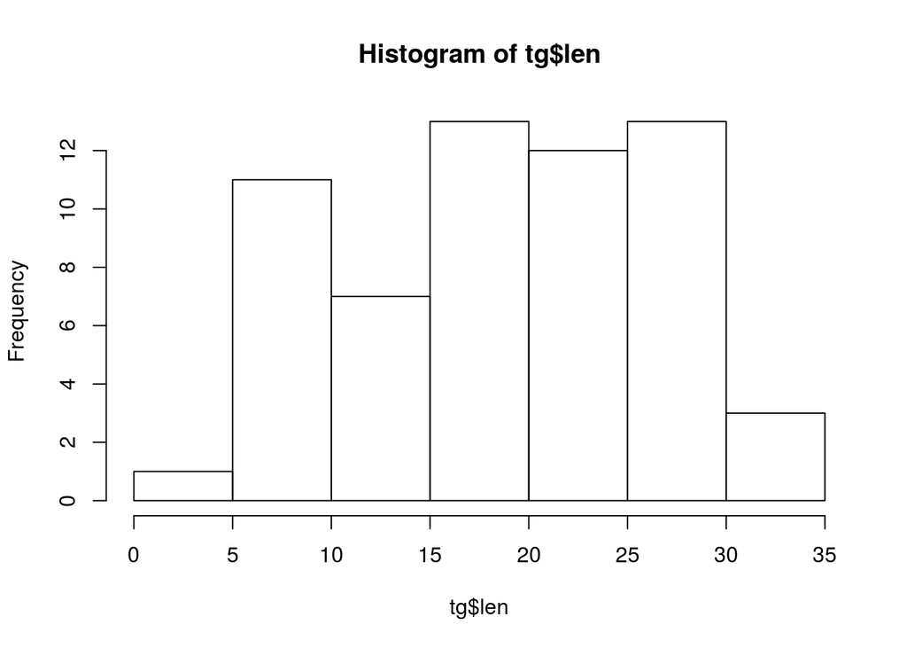

```r
hist(tg$len)
```

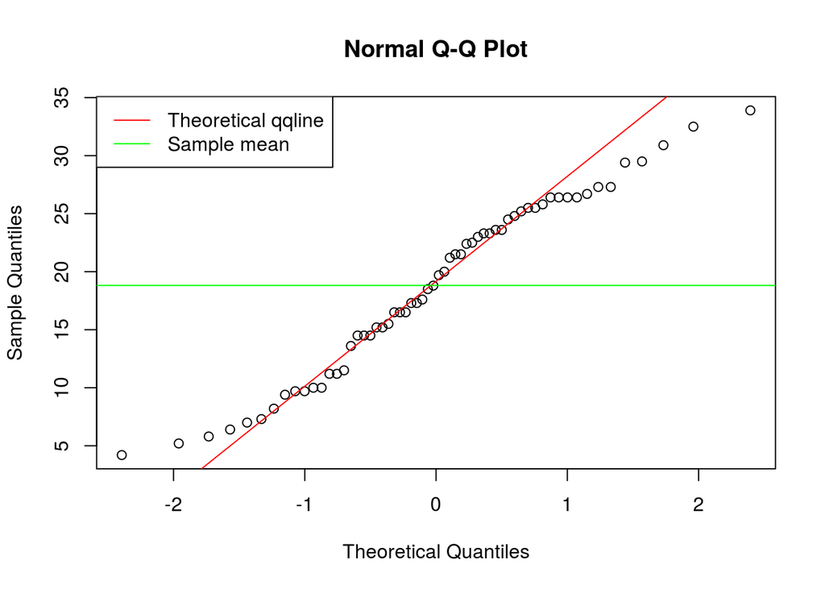

```r
qqnorm(tg$len); qqline(tg$len, col="red"); abline(h=mean(tg$len), col="green")
legend(
    "topleft",
    lty = 1,
    col = c("red", "green"),
    legend = c("Theoretical qqline", "Sample mean")
)
```

#### T-test

##### Test delivery method

Taking the dataset as a whole with each dosage included, the delivery method of vitamin C is not significant at an alpha of 5%.

```r
t.test(len ~ supp, data = tg)
```

```
##
##  Welch Two Sample t-test
##
## data:  len by supp
## t = 1.9153, df = 55.309, p-value = 0.06063
## alternative hypothesis: true difference in means is not equal to 0
## 95 percent confidence interval:
##  -0.1710156  7.5710156
## sample estimates:
## mean in group OJ mean in group VC
##         20.66333         16.96333
```

The delivery method was then tested using t-tests for each dosage. The p-values were corrected for multiple testing. It was found that at 0.5 and 1 mg/day the delivery methods differed significantly. There was no statistical difference at 2 mg/day.

```r
## Dosage of 0.5 mg/day
pval1 <- t.test(len ~ supp, data = tg[tg$dose == 0.5,])$p.value
## Dosage of 1 mg/day
pval2 <- t.test(len ~ supp, data = tg[tg$dose == 1,])$p.value
## Dosage of 2 mg/day
pval3 <- t.test(len ~ supp, data = tg[tg$dose == 2,])$p.value

## Adjust the p-values to correct for multiple testing
padj_vals <- p.adjust(c(pval1, pval2, pval3), method = "BH")
names(padj_vals) <- c("0.5 mg/day", "1 mg/day", "2 mg/day")
padj_vals
```

```
##  0.5 mg/day    1 mg/day    2 mg/day
## 0.009537910 0.003115128 0.963851589
```

### Conclusion

Combining the information from the T-tests and the boxplot it can be said that Vitamin-C delivery is more effective at increasing tooth growth when administered via orange juice at doses of 0.5 and 1 mg/day. At the higher dose of 2 mg/day, the delivery method does not have a significant effect.